# 一些R语言学习的经验分享

muzhi

2017/12/9

## R 语言简介

### R 语言有什么用呢？

R 语言是一个非常适合对编程没有基础的初学者学习的语言。她不仅仅是一个统计分析软件，它还可以自由编程。她是免费，开源的软件。由于她有大量使用者，爱好者，贡献者以及R语言社区，所以有许多免费的packages可以使用。这些packages大都有C，C++编写，我们只要用很简单的编程方式就可以调用进行很复杂，高效的算法。

R语言可以进行统计分析，数据挖掘，机器学习，开发可视化，形成优秀的分析报告等等。R的优势在于：

- 有完善的开源社区，大量的Geek
- 简洁的语法，对于初学者非常友好
- 非常非常好的数据可视化，还可以制作交互的数据产品
- 是一个站在建模角度的语言，不需要在意太多后台。数据结构等等

### 如何安装 R呢

- 安装 [R GUi](https://www.r-project.org)
  - 在官网通过很简单的操作就可以安装最新版本的
  - 注意选择适合你操作系统的最新版本
  - 建议安装时选择默认选项
- 安装 [RStudio](https://www.rstudio.com)
  - 安装RGUi之后建议包安装RStudio，这是一个R的很长好的IDE平台。
  - 请选择RGUi的对应对应版本

这样你就已经搭建一个一个*非常完美*的R语言开发使用平台了

## R语言学习

### 先跑起来吧

R语言的可视化能力很强，图很漂亮。这里对R语言自带数据集mtcars进行探索

- 查看数据集

```r
#查看数据集的一个summary报告
summary(mtcars)
```

```
##       mpg             cyl             disp             hp
##  Min.   :10.40   Min.   :4.000   Min.   : 71.1   Min.   : 52.0
##  1st Qu.:15.43   1st Qu.:4.000   1st Qu.:120.8   1st Qu.: 96.5
##  Median :19.20   Median :6.000   Median :196.3   Median :123.0
##  Mean   :20.09   Mean   :6.188   Mean   :230.7   Mean   :146.7
##  3rd Qu.:22.80   3rd Qu.:8.000   3rd Qu.:326.0   3rd Qu.:180.0
##  Max.   :33.90   Max.   :8.000   Max.   :472.0   Max.   :335.0
##       drat             wt             qsec             vs
##  Min.   :2.760   Min.   :1.513   Min.   :14.50   Min.   :0.0000
##  1st Qu.:3.080   1st Qu.:2.581   1st Qu.:16.89   1st Qu.:0.0000
##  Median :3.695   Median :3.325   Median :17.71   Median :0.0000
##  Mean   :3.597   Mean   :3.217   Mean   :17.85   Mean   :0.4375
##  3rd Qu.:3.920   3rd Qu.:3.610   3rd Qu.:18.90   3rd Qu.:1.0000
##  Max.   :4.930   Max.   :5.424   Max.   :22.90   Max.   :1.0000
##        am              gear            carb
##  Min.   :0.0000   Min.   :3.000   Min.   :1.000
##  1st Qu.:0.0000   1st Qu.:3.000   1st Qu.:2.000
##  Median :0.0000   Median :4.000   Median :2.000
##  Mean   :0.4062   Mean   :3.688   Mean   :2.812
##  3rd Qu.:1.0000   3rd Qu.:4.000   3rd Qu.:4.000
##  Max.   :1.0000   Max.   :5.000   Max.   :8.000
```

```r
#查看前n的数据
head(mtcars, n = 5)
```

|  | mpg | cyl | disp | hp | drat | wt | qsec | vs | am | gear | carb |
| --- | --- | --- | --- | --- | --- | --- | --- | --- | --- | --- | --- |
| Mazda RX4 | 21.0 | 6 | 160 | 110 | 3.90 | 2.620 | 16.46 | 0 | 1 | 4 | 4 |
| Mazda RX4 Wag | 21.0 | 6 | 160 | 110 | 3.90 | 2.875 | 17.02 | 0 | 1 | 4 | 4 |
| Datsun 710 | 22.8 | 4 | 108 | 93 | 3.85 | 2.320 | 18.61 | 1 | 1 | 4 | 1 |
| Hornet 4 Drive | 21.4 | 6 | 258 | 110 | 3.08 | 3.215 | 19.44 | 1 | 0 | 3 | 1 |
| Hornet Sportabout | 18.7 | 8 | 360 | 175 | 3.15 | 3.440 | 17.02 | 0 | 0 | 3 | 2 |

```r
#数据集类型
class(mtcars)
```

```
## [1] "data.frame"
```

```r
#数据的维度
dim(mtcars)
```

```
## [1] 32 11
```

```r
#每个列变量的名称
colnames(mtcars)
```

```
##  [1] "mpg"  "cyl"  "disp" "hp"   "drat" "wt"   "qsec" "vs"   "am"   "gear"
## [11] "carb"
```

- 利用`ggplot2`可视化

```r
#
install.packages('ggplot2')
```

```r
#
library(ggplot2)
```

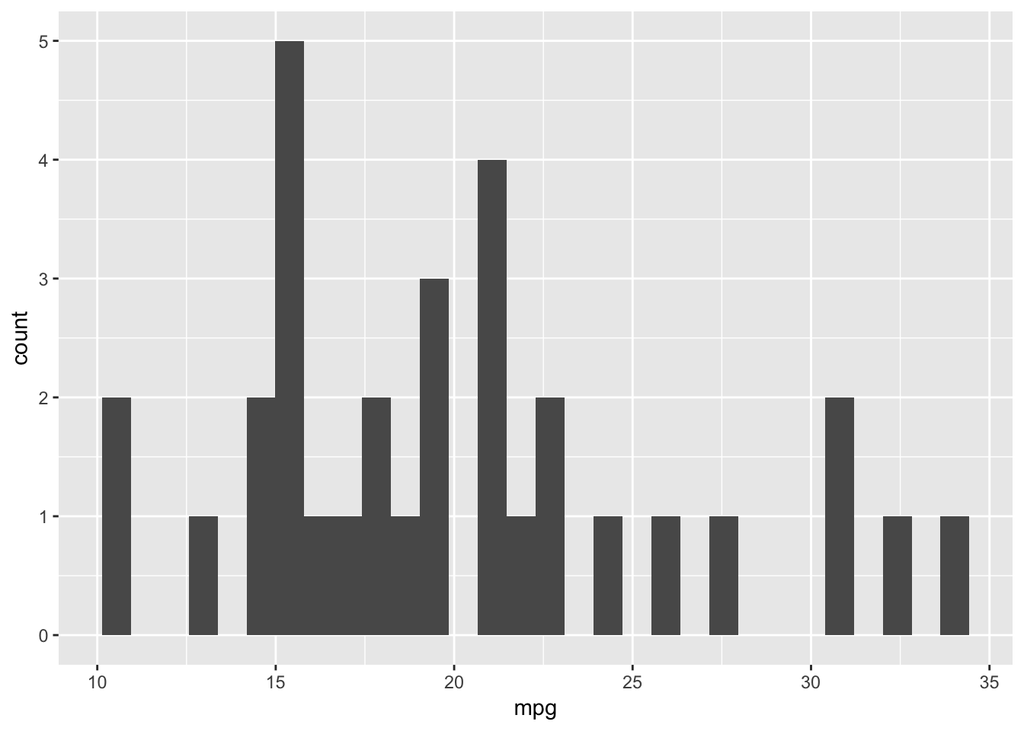

```r
#查看mpg取值分布
ggplot(data = mtcars) + geom_histogram(aes(mpg))
```

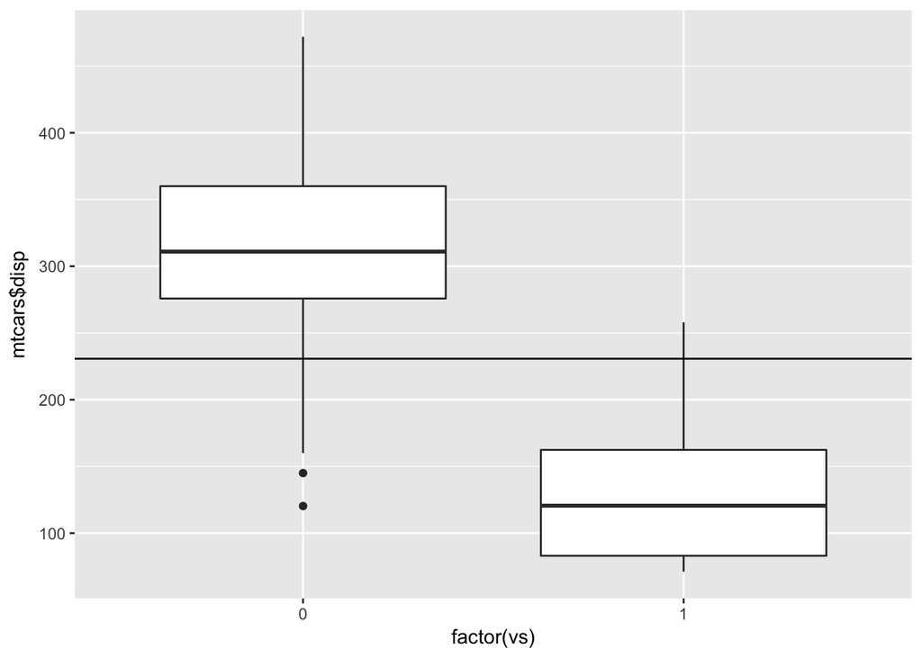

```r
#利用相型图查看 vs 两个取值的disp分布
ggplot(data = mtcars) + geom_boxplot(aes(x =factor(vs), y = mtcars$disp)) +
  geom_hline( yintercept = mean(mtcars$disp) )
```

- 用 `corrplot` 包 查看 变量之间的相关性

```r
install.packages('corrplot')
```

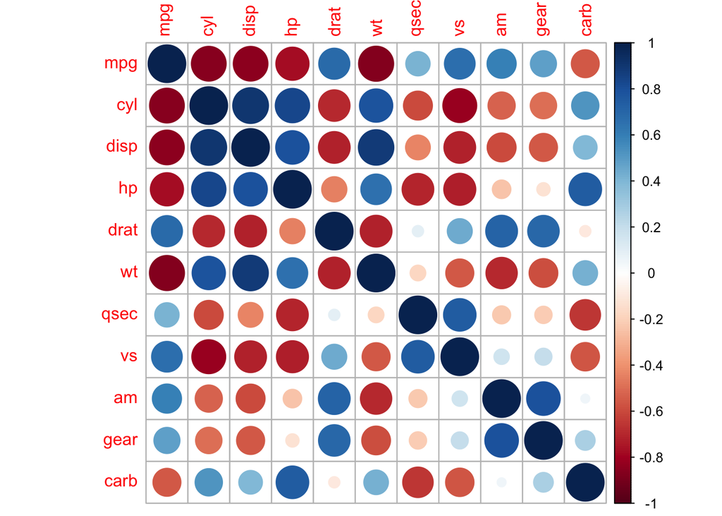

```r
library(corrplot)
M <- cor(mtcars)
corrplot(M)
```

## 总结

### Tips

- 现在你已经知道如何安装，并加载packages。一般当你遇到问题，在budai或者google上搜索相关的问题一般就可得到答案。请记住，当你要实现一个比较复杂的功能时，首先先去查查有没有相关的packages，博客等等，再去着手解决。初学者一般不要造轮子。
- 推荐你去看《R语言实战》这本书，了解R语言的基本语法，基本功能。不用完全读懂，把它当成一个手册，需要时翻翻就好。
- 当你了解基本语法之后，找一些练手的项目。比如对数据挖掘感兴趣可以在kaggle上参加比赛学习。
- 学会查看help文档 `?corrplot`
- 学会科学上网，建议把R的默认下载路径更改为国内，否则下载packages的速度会很慢。

### R语言学习路径

#### 入门

- 学习《R语言实战》了解一些简单算法使用R进行来练手
- 在[coursera](https://www.coursera.org/specializations/jhu-data-science)上学习 霍普金斯大学的 **Data Science**课程

#### 进阶

- 想做自然语言处理的同学可以看看《基于R语言自动数据收集》较难 讲解如何制作R语言爬虫，如何处理文本数据
- 对机器学习需要，可以看看《统计学习导论基于R应用》[英文版免费](http://www-bcf.usc.edu/~gareth/ISL/)这是一本非常棒的书，如果以后机器学习的话，一定要看。

#### 更进一步 放弃

- R语言高级编程指南
- R的极客理想系列
- 看看别人的学习建议[该如何学习 R 语言？](https://www.zhihu.com/question/21654166) [R语言学习由浅入深路线图](http://blog.csdn.net/lgdblue/article/details/42678233)

### 推荐 R packages

- `ggplot2` 很厉害的绘图包
- `rmarkdown` markdwon的R语言版，可以制作比较精美的报告，将代码和写作联系起来。本文就是利用rmarkdown完成的。
- `stringr` 文本，字符串处理
- `plyr` 整合，分割数据
- [相关推荐](https://www.zhihu.com/question/21792740)